# SAVI case study — universal healthy baseline

```r
handlers("progress")

sting_fit_rows <- sting_estimates_chunk |>
  dplyr::filter(.data$compression_ok == TRUE) |>
  dplyr::filter(lengths(.data$brms_fit_compressed) > 0L) |>
  dplyr::filter(.data$.feature %in% rownames(se_monocytic))

if (!nrow(sting_fit_rows)) {
  stop("No compressed biomarker fits available; run with params$run_fits: true or fix estimates_rds.")
}

with_progress({
  p <- progressr::progressor(steps = nrow(sting_fit_rows) * nrow(comparison_samples_tbl))

  sting_gene_results <- purrr::imap(
    seq_len(nrow(sting_fit_rows)),
    function(i, idx) {
      chunk_row <- sting_fit_rows[i, ]
      feature_id <- chunk_row$.feature
      gene_sym <- chunk_row$gene
      fit <- poco::reconstruct_brmsfit(chunk_row$brms_fit_compressed[[1]])

      baseline <- healthy_predictive_draws_for_fit(
        fit,
        newdata = newdata_universal_baseline()
      )

      deviations <- purrr::pmap_dfr(
        comparison_samples_tbl |>
          dplyr::select("sample", "sample_idx", "sample_role"),
        function(sample, sample_idx, sample_role) {
          p()

          obs <-
            SummarizedExperiment::assay(
              se_monocytic[feature_id, sample_idx, drop = FALSE],
              scaled_counts_assay_name(se_monocytic)
            ) |>
            as.numeric()

          gene_deviation_from_draws(
            baseline$y_rep,
            obs,
            n_grid_rows = baseline$n_grid_rows
          ) |>
            dplyr::mutate(
              .feature = feature_id,
              gene = gene_sym,
              sample = as.character(sample),
              sample_role = as.character(sample_role),
              .before = "observed_scaled"
            )
        }
      )

      list(
        deviations = deviations,
        baseline = tibble::tibble(
          gene = gene_sym,
          .feature = feature_id,
          counts_scaled = list(baseline$y_rep),
          n_draws = baseline$n_draws,
          n_grid_rows = baseline$n_grid_rows,
          predict_type = baseline$predict_type,
          marginalize_method = baseline$marginalize_method
        )
      )
    }
  )
})

gene_deviation_all <- purrr::map_dfr(sting_gene_results, "deviations")

gene_baseline_draws_store <- dplyr::bind_rows(
  purrr::map(sting_gene_results, "baseline")
)

gene_baseline_draws <- gene_baseline_draws_as_long(gene_baseline_draws_store)

baseline_draws_dir <- dirname(params$gene_baseline_draws_rds)
if (!dir.exists(baseline_draws_dir)) {
  dir.create(baseline_draws_dir, recursive = TRUE, showWarnings = FALSE)
}
saveRDS(gene_baseline_draws_store, params$gene_baseline_draws_rds, compress = "xz")

tibble::tibble(
  n_genes_with_baseline_draws = nrow(gene_baseline_draws_store),
  n_draw_rows_long = nrow(gene_baseline_draws),
  baseline_predict_type = params$baseline_predict_type,
  baseline_marginalize_method = params$baseline_marginalize_method,
  saved_to = params$gene_baseline_draws_rds
)
```

| n_genes_with_baseline_draws | n_draw_rows_long | baseline_predict_type | baseline_marginalize_method | saved_to |
| --- | --- | --- | --- | --- |
| 16 | 5376000 | predict | pool | /hpcfs/groups/phoenix-hpc-mangiola_laboratory/chen/posteriorHCA/dev/SAVI/data/SAVI_gene_baseline_draws_universal.rds |

```r
gene_deviation_all <- gene_deviation_all |>
  tibble::as_tibble() |>
  dplyr::select(tidyselect::where(\(x) !is.list(x)))

if (!"sample_role" %in% colnames(gene_deviation_all)) {
  gene_deviation_all <- gene_deviation_all |>
    dplyr::left_join(
      comparison_samples_tbl |>
        dplyr::select("sample", "sample_role"),
      by = "sample"
    )
}

gene_deviation_all
```

| .feature | gene | sample | sample_role | observed_scaled | healthy_median | healthy_mean | healthy_hpd_lo | healthy_hpd_hi | obs_percentile | p_above_healthy | p_below_healthy | posterior_tail_p | log2fc_vs_median | n_grid_rows | direction |
| --- | --- | --- | --- | --- | --- | --- | --- | --- | --- | --- | --- | --- | --- | --- | --- |
| ENSG00000169252 | ADRB2 | C1_17. Disease-associated monocytes | savi_pseudobulk | 42.10146 | 17 | 9.474276e+07 | 0 | 3402 | 0.5910952 | 0.40890476 | 0.5910952 | 0.81780952 | 1.2597398 | 840 | consistent_with_healthy |
| ENSG00000169252 | ADRB2 | C10_17. Disease-associated monocytes | savi_pseudobulk | 0.00000 | 17 | 9.474276e+07 | 0 | 3402 | 0.3627440 | 1.00000000 | 0.3627440 | 0.72548810 | -4.1699250 | 840 | consistent_with_healthy |
| ENSG00000169252 | ADRB2 | C11_17. Disease-associated monocytes | savi_pseudobulk | 0.00000 | 17 | 9.474276e+07 | 0 | 3402 | 0.3627440 | 1.00000000 | 0.3627440 | 0.72548810 | -4.1699250 | 840 | consistent_with_healthy |
| ENSG00000169252 | ADRB2 | C2_17. Disease-associated monocytes | savi_pseudobulk | 64.88019 | 17 | 9.474276e+07 | 0 | 3402 | 0.6394940 | 0.36050595 | 0.6394940 | 0.72101190 | 1.8718478 | 840 | consistent_with_healthy |
| ENSG00000169252 | ADRB2 | C7_17. Disease-associated monocytes | savi_pseudobulk | 0.00000 | 17 | 9.474276e+07 | 0 | 3402 | 0.3627440 | 1.00000000 | 0.3627440 | 0.72548810 | -4.1699250 | 840 | consistent_with_healthy |
| ENSG00000169252 | ADRB2 | C8-aunt-P1-STING_17. Disease-associated monocytes | savi_pseudobulk | 0.00000 | 17 | 9.474276e+07 | 0 | 3402 | 0.3627440 | 1.00000000 | 0.3627440 | 0.72548810 | -4.1699250 | 840 | consistent_with_healthy |
| ENSG00000169252 | ADRB2 | C9-mother-P1-STING_17. Disease-associated monocytes | savi_pseudobulk | 0.00000 | 17 | 9.474276e+07 | 0 | 3402 | 0.3627440 | 1.00000000 | 0.3627440 | 0.72548810 | -4.1699250 | 840 | consistent_with_healthy |
| ENSG00000169252 | ADRB2 | P1-STING-ht_17. Disease-associated monocytes | savi_pseudobulk | 111.38929 | 17 | 9.474276e+07 | 0 | 3402 | 0.7056577 | 0.29434226 | 0.7056577 | 0.58868452 | 2.6424357 | 840 | consistent_with_healthy |
| ENSG00000169252 | ADRB2 | P1-STING-ht-T_17. Disease-associated monocytes | savi_pseudobulk | 62.33182 | 17 | 9.474276e+07 | 0 | 3402 | 0.6357113 | 0.36428869 | 0.6357113 | 0.72857738 | 1.8149337 | 840 | consistent_with_healthy |
| ENSG00000169252 | ADRB2 | P1-STING-ht-T2_17. Disease-associated monocytes | savi_pseudobulk | 118.35645 | 17 | 9.474276e+07 | 0 | 3402 | 0.7128958 | 0.28710417 | 0.7128958 | 0.57420833 | 2.7292077 | 840 | consistent_with_healthy |

[output cut: 278 more lines]

```r
gene_deviation_all |>
  dplyr::count(.data$sample_role, .data$direction) |>
  tidyr::pivot_wider(
    names_from = "direction",
    values_from = "n",
    values_fill = 0L
  )
```

| sample_role | consistent_with_healthy | higher_than_healthy |
| --- | --- | --- |
| reference | 16 | 0 |
| savi_pseudobulk | 266 | 6 |

```r
gene_deviation_savi <- gene_deviation_all |>
  dplyr::filter(.data$sample_role == "savi_pseudobulk")

gene_deviation_savi |>
  dplyr::group_by(.data$gene) |>
  dplyr::summarise(
    n_higher = sum(.data$direction == "higher_than_healthy"),
    n_lower = sum(.data$direction == "lower_than_healthy"),
    n_consistent = sum(.data$direction == "consistent_with_healthy"),
    .groups = "drop"
  ) |>
  dplyr::arrange(dplyr::desc(.data$n_higher + .data$n_lower))
```

| gene | n_higher | n_lower | n_consistent |
| --- | --- | --- | --- |
| PTGS2 | 2 | 0 | 15 |
| ANKRD28 | 1 | 0 | 16 |
| ANXA1 | 1 | 0 | 16 |
| OTUD1 | 1 | 0 | 16 |
| TGIF1 | 1 | 0 | 16 |
| ADRB2 | 0 | 0 | 17 |
| AQP9 | 0 | 0 | 17 |
| IL1B | 0 | 0 | 17 |
| JARID2 | 0 | 0 | 17 |
| KLF4 | 0 | 0 | 17 |

[output cut: 6 more lines]

# Non-parametric tests vs universal null (three cohorts)

Empirical tail tests above (`p_above_healthy`, `direction`) are **per donor × gene**: each pseudobulk value is compared to the same gene-specific null draw vector. Here we add **cohort-level** non-parametric tests that pool the small number of donors within each study arm (**CTRL**, **SAVI_treated**, **SAVI**) and ask whether those values look like draws from the universal atlas null, or sit systematically above it.

**Paper expectation (STING signature, monocytes):** expression is highest in untreated **SAVI**, intermediate in **SAVI_treated**, and lowest (near atlas healthy) in **CTRL**. We therefore look for:

| Cohort | vs universal null | vs other cohorts |
| --- | --- | --- |
| **SAVI** | Strongest evidence of **elevation** (small p-values; high percentiles) | Highest descriptives |
| **SAVI_treated** | Weaker elevation than SAVI | Between CTRL and SAVI |
| **CTRL** | **No** elevation (large p-values; percentiles near 0.5) | Lowest descriptives |

All one-sided tests below use **elevation** as the alternative (cohort **above** the null). They do **not** test SAVI vs CTRL directly unless noted in the signature-level section.

## Setup

For each biomarker gene we reuse the **same** null vector `y_rep` from `brms_universal_null_draws()` (one per gene, shared across all donors). For a given cohort we collect `n` observed `counts_scaled` values (typically a few pseudobulk donors per arm) and compare that **set** to `y_rep`.

Two layers:

1. **Gene × cohort** (`gene_np_by_cohort`): “Are SAVI donors for *IL1B* elevated vs the IL1B null?” — repeated for every gene and cohort.
2. **Donor signature** (`np_signature_order_summary`): aggregate across genes per donor, then compare **cohorts to each other** (no null in this step).

## Shortlist of approaches

| ID | Test | Question | One-sided? | Typical n |
| --- | --- | --- | --- | --- |
| **A** | **Empirical mean** (`p_empirical_mean`) | Is the **cohort mean** unusually high vs null draws? P(null ≥ mean(obs)) | Yes | any |
| **B** | **Binomial exceed median** (`p_binom_exceed_median`) | Do **more than half** of cohort donors exceed median(null)? | Yes | ≈5 donors |
| **C** | **Wilcoxon–Mann–Whitney** (`p_wilcox_vs_null`) | Are cohort values **stochastically larger** than null draws? | Yes | any |
| **D** | **Kolmogorov–Smirnov** (`p_ks_greater`) | Is the cohort ECDF shifted **right** vs null ECDF? | Yes | n ≥ 2 |
| **E** | **Permutation mean** (`p_perm_mean`) | If we drew `n` values from the null, how often is their mean ≥ observed cohort mean? | Yes | any |
| **F** | **Wilcoxon signed-rank** (`p_wilcox_vs_median`) | Are (obs − median(null)) **positive**? | Yes | n ≥ 2 |
| **G** | **Mean obs percentile** (`mean_obs_percentile`) | Average rank of cohort obs in null ECDF (descriptive) | — | any |
| **H** | **Kruskal–Wallis** | Do **donor signature scores** differ across the three cohorts? | — | donors |
| **I** | **Pairwise Wilcoxon** | Post-hoc SAVI vs CTRL, etc. on donor scores (BH) | Partial | donors |
| **J** | **Spearman trend** | Monotone increase CTRL → treated → SAVI on donor scores | Yes | donors |

**Intuition for A–F:** the null is an **empirical distribution** (thousands of predictive draws), not Normal(μ, σ). These tests ask whether the **cohort’s values** could have been drawn from that reference, or sit in the **upper tail** (STING activation).

**Caveats:** MCMC draws are **dependent**; genes are **correlated**. **Stouffer** combination across genes is **exploratory** only. Wilcoxon/KS **subsample** 2000 null draws when `pool` is used (speed); empirical/permutation tests use the full vector.

## How to read each output column

### `gene_np_by_cohort` (one row = one gene × one cohort)

| Column | Meaning | “Better” for reproducing paper trend |
| --- | --- | --- |
| `n_obs` | Donors in that cohort with data for this gene | — |
| `n_null_draws` | Length of null vector for this gene | — |
| `mean_obs` | Mean `counts_scaled` in the cohort | **Higher** in SAVI > treated > CTRL (on average across genes) |
| `median_null` | Median of null draws | Reference only |
| `mean_obs_percentile` | Mean of P(null ≤ obs) over cohort donors; **0.5** if exchangeable with null | **Higher** = further above null. Expect **SAVI highest**, CTRL **near 0.5** |
| `frac_obs_above_median_null` | Fraction of cohort donors with obs > median(null); **0.5** under null | **Higher** for SAVI. Expect **SAVI > treated > CTRL** |
| `p_empirical_mean` … `p_wilcox_vs_median` | One-sided p-values for **elevation** vs null | **Smaller** = stronger evidence of elevation. Expect **SAVI smallest**, **CTRL largest** (often > 0.05) |

**Important:** for **p-values**, **lower is “better”** (more evidence against the null / more elevation). For **percentiles and fractions**, **higher is “better”** (more elevated). Do not interpret a **large** p-value for SAVI as “good” — that would mean **no** elevation detected.

### `gene_np_cohort_effects` (cohort summaries averaged over genes)

| Column | Meaning | Expected ordering |
| --- | --- | --- |
| `mean_mean_obs_percentile` | Average of `mean_obs_percentile` across genes | **SAVI > SAVI_treated > CTRL** |
| `mean_frac_obs_above_median_null` | Average fraction above null median | **SAVI > SAVI_treated > CTRL** |
| `mean_mean_obs` | Average cohort mean expression (gene-specific scales mixed) | Directionally SAVI > treated > CTRL; interpret with caution |
| `mean_p_*` | Mean of gene-level p-values in that cohort | **SAVI lowest**, CTRL highest (less significant) |
| `n_gene_cohort_tests` | Number of genes | — |

### `gene_np_stouffer` / `stouffer_by_test` (omnibus across genes)

| Column | Meaning | Expected |
| --- | --- | --- |
| `stouffer_p` | Combined one-sided evidence that **this cohort** is elevated across all genes | **Smaller** for SAVI. Expect **stouffer_p_SAVI < stouffer_p_SAVI_treated < stouffer_p_CTRL** |
| `median_p` | Median gene-level p in that cohort | Same direction as Stouffer (lower for SAVI) |
| `stouffer_ordering_ok` | TRUE if SAVI has smallest Stouffer p among the three cohorts | TRUE = matches paper |

### `gene_np_trend_check` (`descriptive_trend`)

| Column | Meaning |
| --- | --- |
| `CTRL`, `SAVI_treated`, `SAVI` | Cohort values for each descriptive metric |
| `ordering_ok` | TRUE if **SAVI > SAVI_treated > CTRL** for that metric (higher = more elevated) |

### `np_signature_order_summary` (donor-level, no null)

| Column | Meaning | Expected |
| --- | --- | --- |
| `mean_obs_percentile` | Donor mean rank in null, averaged over genes | **Higher** for SAVI donors |
| `mean_log2fc` | Donor mean log2(obs / null median) | **Higher** for SAVI |
| `signature_score` | Donor mean direction score (+1 higher, 0 consistent, −1 lower) | **Higher** for SAVI |
| `kruskal_p` | Any difference across cohorts? | **Small** if cohorts separate |
| `spearman_trend_p` | Monotone trend CTRL < treated < SAVI? | **Small** if paper ordering holds |
| `spearman_rho` | Strength of trend; **positive** if SAVI > treated > CTRL | **Positive**, larger is better |

Pairwise Wilcoxon matrices (printed below the table): look for **SAVI > CTRL** and **SAVI > SAVI_treated** with **small adjusted p-values** (row/col labels show which cohort is tested as greater).

## Quick reference: higher or lower?

| Metric type | SAVI (expect) | CTRL (expect) | Compare cohorts |
| --- | --- | --- | --- |
| Percentiles, fractions, log2fc, signature score | **High** | **Moderate / ~0.5** | **Higher = more STING-like** |
| p-values (gene or Stouffer) | **Low** (< 0.05 if strong) | **High** (often ≫ 0.05) | **Lower p = more elevated vs null** |
| Spearman ρ (trend) | — | — | **Positive ρ** with small trend p |

```r
savi_cohort_annotations <- cd_mono |>
  dplyr::filter(.data$sample_role == "savi_pseudobulk") |>
  dplyr::select("sample", tidyselect::any_of(c("Sample", "Category"))) |>
  dplyr::distinct() |>
  dplyr::mutate(
    Category = factor(
      .data$Category,
      levels = c("CTRL", "SAVI_treated", "SAVI")
    )
  )

gene_obs_cohort <- gene_deviation_savi |>
  dplyr::left_join(savi_cohort_annotations, by = "sample") |>
  dplyr::filter(!is.na(.data$Category))

tibble::tibble(
  n_genes = dplyr::n_distinct(gene_obs_cohort$gene),
  n_per_category = gene_obs_cohort |>
    dplyr::distinct(.data$sample, .data$Category) |>
    dplyr::count(.data$Category)
)
```

[output not shown]

```r
gene_np_by_cohort <- purrr::map_dfr(
  unique(gene_baseline_draws_store$gene),
  function(gene_sym) {
    row <- gene_baseline_draws_store |>
      dplyr::filter(.data$gene == .env$gene_sym)
    if (!nrow(row)) {
      return(NULL)
    }
    y_rep <- row$counts_scaled[[1L]]

    purrr::map_dfr(
      levels(savi_cohort_annotations$Category),
      function(cat) {
        obs <- gene_obs_cohort |>
          dplyr::filter(
            .data$gene == .env$gene_sym,
            .data$Category == .env$cat
          ) |>
          dplyr::pull(.data$observed_scaled)

        test_obs_vs_null_draws(obs, y_rep, seed = params$seed) |>
          dplyr::mutate(
            gene = gene_sym,
            Category = cat,
            .before = 1L
          )
      }
    )
  }
)

gene_np_by_cohort
```

| gene | Category | n_obs | n_null_draws | mean_obs | median_null | mean_obs_percentile | frac_obs_above_median_null | p_empirical_mean | p_binom_exceed_median | p_wilcox_vs_null | p_ks_greater | p_perm_mean | p_wilcox_vs_median |
| --- | --- | --- | --- | --- | --- | --- | --- | --- | --- | --- | --- | --- | --- |
| ADRB2 | CTRL | 7 | 336000 | 15.28309 | 17 | 0.4385714 | 0.2857143 | 0.50607440 | 0.9375000 | 0.9656131042 | 0.1458127 | 0.9578 | 0.60376996 |
| ADRB2 | SAVI_treated | 5 | 336000 | 516.95117 | 17 | 0.8182000 | 1.0000000 | 0.13654167 | 0.0312500 | 0.0057935372 | 0.9411166 | 0.2838 | 0.02952911 |
| ADRB2 | SAVI | 5 | 336000 | 924.63143 | 17 | 0.7165000 | 0.8000000 | 0.09850298 | 0.1875000 | 0.0770997949 | 0.9813017 | 0.2110 | 0.05282271 |
| ANKRD28 | CTRL | 7 | 336000 | 1199.66417 | 26 | 0.8577857 | 1.0000000 | 0.05951190 | 0.0078125 | 0.0005009689 | 0.9830550 | 0.1532 | 0.01124714 |
| ANKRD28 | SAVI_treated | 5 | 336000 | 4379.58189 | 26 | 0.9736000 | 1.0000000 | 0.02976786 | 0.0312500 | 0.0001151727 | 0.9953996 | 0.0770 | 0.02952911 |
| ANKRD28 | SAVI | 5 | 336000 | 3690.30732 | 26 | 0.9556000 | 1.0000000 | 0.03192857 | 0.0312500 | 0.0001983991 | 0.9947371 | 0.0864 | 0.02952911 |
| ANXA1 | CTRL | 7 | 336000 | 6858.14787 | 995 | 0.8371429 | 1.0000000 | 0.11960714 | 0.0078125 | 0.0010228156 | 0.9768209 | 0.1794 | 0.01124714 |
| ANXA1 | SAVI_treated | 5 | 336000 | 7407.43890 | 995 | 0.8830000 | 1.0000000 | 0.11061607 | 0.0312500 | 0.0015285869 | 0.9432947 | 0.1574 | 0.02952911 |
| ANXA1 | SAVI | 5 | 336000 | 21980.83203 | 995 | 0.8988000 | 1.0000000 | 0.03758333 | 0.0312500 | 0.0010207953 | 0.9976064 | 0.0720 | 0.02952911 |
| AQP9 | CTRL | 7 | 336000 | 317.94332 | 5 | 0.8200000 | 1.0000000 | 0.17329762 | 0.0078125 | 0.0011508475 | 0.8757949 | 0.4238 | 0.01124714 |

[output cut: 38 more lines]

Per-gene results: filter `gene_np_by_cohort` for a gene of interest, or sort by `mean_obs_percentile` within `Category == "SAVI"`.

```r
p_cols <- c(
  "p_empirical_mean",
  "p_binom_exceed_median",
  "p_wilcox_vs_null",
  "p_ks_greater",
  "p_perm_mean",
  "p_wilcox_vs_median"
)

gene_np_cohort_effects <- gene_np_by_cohort |>
  dplyr::group_by(.data$Category) |>
  dplyr::summarise(
    dplyr::across(
      c(
        .data$mean_obs_percentile,
        .data$frac_obs_above_median_null,
        .data$mean_obs,
        dplyr::all_of(p_cols)
      ),
      ~ mean(.x, na.rm = TRUE),
      .names = "mean_{.col}"
    ),
    n_gene_cohort_tests = dplyr::n(),
    .groups = "drop"
  ) |>
  dplyr::arrange(.data$Category)

gene_np_stouffer <- gene_np_by_cohort |>
  tidyr::pivot_longer(
    dplyr::all_of(p_cols),
    names_to = "test",
    values_to = "p"
  ) |>
  dplyr::group_by(.data$Category, .data$test) |>
  dplyr::summarise(
    stouffer_p = stouffer_one_sided(.data$p, alternative = "greater"),
    median_p = stats::median(.data$p, na.rm = TRUE),
    n_genes = dplyr::n(),
    .groups = "drop"
  ) |>
  dplyr::arrange(.data$test, .data$Category)

gene_np_cohort_effects
```

| Category | mean_mean_obs_percentile | mean_frac_obs_above_median_null | mean_mean_obs | mean_p_empirical_mean | mean_p_binom_exceed_median | mean_p_wilcox_vs_null | mean_p_ks_greater | mean_p_perm_mean | mean_p_wilcox_vs_median | n_gene_cohort_tests |
| --- | --- | --- | --- | --- | --- | --- | --- | --- | --- | --- |
| CTRL | 0.7722143 | 0.9285714 | 1603.595 | 0.1800908 | 0.07617188 | 0.069298834 | 0.8201511 | 0.3658500 | 0.04946012 | 16 |
| SAVI | 0.8694188 | 0.9625000 | 5609.665 | 0.0656529 | 0.06054687 | 0.009337702 | 0.9830766 | 0.1288000 | 0.03389666 | 16 |
| SAVI_treated | 0.8631250 | 1.0000000 | 2989.265 | 0.1102106 | 0.03125000 | 0.007152347 | 0.9455825 | 0.2024125 | 0.02952911 | 16 |

```r
gene_np_stouffer
```

| Category | test | stouffer_p | median_p | n_genes |
| --- | --- | --- | --- | --- |
| CTRL | p_binom_exceed_median | 2.810932e-21 | 0.0078125000 | 16 |
| SAVI | p_binom_exceed_median | 6.823935e-16 | 0.0312500000 | 16 |
| SAVI_treated | p_binom_exceed_median | 3.481888e-18 | 0.0312500000 | 16 |
| CTRL | p_empirical_mean | 1.366290e-08 | 0.1501532738 | 16 |
| SAVI | p_empirical_mean | 2.019084e-14 | 0.0553497024 | 16 |
| SAVI_treated | p_empirical_mean | 2.224879e-11 | 0.0991830357 | 16 |
| CTRL | p_ks_greater | 1.573594e-01 | 0.8608796518 | 16 |
| SAVI | p_ks_greater | 4.661599e-01 | 0.9891959447 | 16 |
| SAVI_treated | p_ks_greater | 3.921695e-01 | 0.9422056172 | 16 |
| CTRL | p_perm_mean | 7.867870e-05 | 0.3494000000 | 16 |

[output cut: 8 more lines]

**`gene_np_cohort_effects`**: descriptive means by cohort (higher percentiles/fractions for SAVI = good). **`gene_np_stouffer`**: omnibus p-values (lower for SAVI = stronger atlas deviation).

```r
# Paper expectation: SAVI > SAVI_treated > CTRL on elevation summaries.
gene_np_trend_check <- gene_np_cohort_effects |>
  dplyr::select(
    Category,
    mean_mean_obs_percentile,
    mean_frac_obs_above_median_null,
    mean_mean_obs
  ) |>
  tidyr::pivot_longer(
    -Category,
    names_to = "metric",
    values_to = "value"
  ) |>
  dplyr::group_by(.data$metric) |>
  dplyr::summarise(
    CTRL = .data$value[.data$Category == "CTRL"],
    SAVI_treated = .data$value[.data$Category == "SAVI_treated"],
    SAVI = .data$value[.data$Category == "SAVI"],
    ordering_ok = .data$SAVI > .data$SAVI_treated & .data$SAVI_treated > .data$CTRL,
    .groups = "drop"
  )

gene_np_stouffer_wide <- gene_np_stouffer |>
  tidyr::pivot_wider(
    id_cols = test,
    names_from = Category,
    values_from = c(stouffer_p, median_p),
    names_sep = "_"
  ) |>
  dplyr::mutate(
    stouffer_ordering_ok = .data$stouffer_p_SAVI < .data$stouffer_p_CTRL &
      .data$stouffer_p_SAVI < .data$stouffer_p_SAVI_treated
  )

list(
  descriptive_trend = gene_np_trend_check,
  stouffer_by_test = gene_np_stouffer_wide
)
```

```
$descriptive_trend
# A tibble: 3 × 5
  metric                              CTRL SAVI_treated     SAVI ordering_ok
  <chr>                              <dbl>        <dbl>    <dbl> <lgl>
1 mean_frac_obs_above_median_null    0.929        1        0.962 FALSE
2 mean_mean_obs                   1604.        2989.    5610.    TRUE
3 mean_mean_obs_percentile           0.772        0.863    0.869 TRUE

$stouffer_by_test
# A tibble: 6 × 8
  test      stouffer_p_CTRL stouffer_p_SAVI stouffer_p_SAVI_trea…¹ median_p_CTRL
  <chr>               <dbl>           <dbl>                  <dbl>         <dbl>
1 p_binom_…        2.81e-21        6.82e-16               3.48e-18       0.00781
2 p_empiri…        1.37e- 8        2.02e-14               2.22e-11       0.150
3 p_ks_gre…        1.57e- 1        4.66e- 1               3.92e- 1       0.861
4 p_perm_m…        7.87e- 5        1.48e-10               6.30e- 8       0.349
5 p_wilcox…        9.01e-22        7.61e-18               1.58e-18       0.0112
6 p_wilcox…        1.78e-28        2.47e-35               8.17e-35       0.00165
# ℹ abbreviated name: ¹stouffer_p_SAVI_treated
# ℹ 3 more variables: median_p_SAVI <dbl>, median_p_SAVI_treated <dbl>,
#   stouffer_ordering_ok <lgl>
```

**`ordering_ok` / `stouffer_ordering_ok`**: TRUE when descriptives or Stouffer p-values follow **SAVI > SAVI_treated > CTRL** (for descriptives, higher; for Stouffer, SAVI has the **smallest** p).

```r
# Donor-level signature scores (no null): Kruskal–Wallis, pairwise Wilcoxon, Spearman trend.
if (!exists("signature_by_sample", inherits = TRUE)) {
  signature_by_sample <- gene_obs_cohort |>
    dplyr::group_by(.data$sample, .data$Sample, .data$Category) |>
    dplyr::summarise(
      n_genes = dplyr::n(),
      mean_obs_percentile = mean(.data$obs_percentile, na.rm = TRUE),
      mean_log2fc = mean(.data$log2fc_vs_median, na.rm = TRUE),
      signature_score = mean(
        dplyr::case_when(
          .data$direction == "higher_than_healthy" ~ 1L,
          .data$direction == "lower_than_healthy" ~ -1L,
          TRUE ~ 0L
        ),
        na.rm = TRUE
      ),
      .groups = "drop"
    )
}

np_order_mean_pct <- test_cohort_ordering(
  signature_by_sample,
  score_var = "mean_obs_percentile"
)
np_order_log2fc <- test_cohort_ordering(
  signature_by_sample,
  score_var = "mean_log2fc"
)
np_order_sig <- test_cohort_ordering(
  signature_by_sample,
  score_var = "signature_score"
)

np_signature_order_summary <- tibble::tribble(
  ~score, ~kruskal_p, ~spearman_trend_p, ~spearman_rho,
  "mean_obs_percentile", np_order_mean_pct$kruskal_p, np_order_mean_pct$spearman_trend_p, np_order_mean_pct$spearman_rho,
  "mean_log2fc", np_order_log2fc$kruskal_p, np_order_log2fc$spearman_trend_p, np_order_log2fc$spearman_rho,
  "signature_score", np_order_sig$kruskal_p, np_order_sig$spearman_trend_p, np_order_sig$spearman_rho
)

np_signature_order_summary
```

| score | kruskal_p | spearman_trend_p | spearman_rho |
| --- | --- | --- | --- |
| mean_obs_percentile | 0.01819292 | 0.002379517 | 0.6497077 |
| mean_log2fc | 0.01819292 | 0.002379517 | 0.6497077 |
| signature_score | 0.47236655 | 0.130437992 | 0.2888254 |

```r
list(
  pairwise_mean_percentile_bh = np_order_mean_pct$pairwise_wilcox_bh,
  pairwise_log2fc_bh = np_order_log2fc$pairwise_wilcox_bh,
  pairwise_signature_bh = np_order_sig$pairwise_wilcox_bh
)
```

```
$pairwise_mean_percentile_bh

    Pairwise comparisons using Wilcoxon rank sum test with continuity correction

data:  score and catf

             CTRL  SAVI_treated
SAVI_treated 0.014 -
SAVI         0.038 0.338

P value adjustment method: BH

$pairwise_log2fc_bh

    Pairwise comparisons using Wilcoxon rank sum test with continuity correction

data:  score and catf

             CTRL  SAVI_treated
SAVI_treated 0.014 -
SAVI         0.038 0.338

P value adjustment method: BH

$pairwise_signature_bh

    Pairwise comparisons using Wilcoxon rank sum test with continuity correction

data:  score and catf

             CTRL SAVI_treated
SAVI_treated 0.23 -
SAVI         0.23 0.50

P value adjustment method: BH
```

Donor-level tests do not use the null directly; they ask whether **SAVI donors score higher** than CTRL/treated on aggregated signature metrics. Small **`kruskal_p`** or **`spearman_trend_p`** with **positive `spearman_rho`** support the paper ordering.

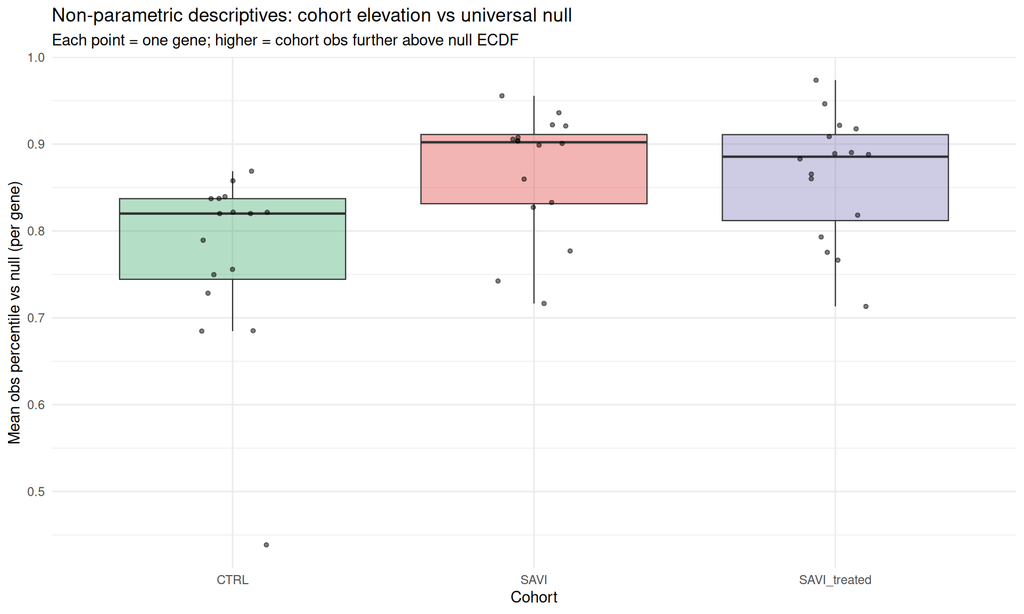

```r
category_cols_np <- c(
  CTRL = "#2ca25f",
  SAVI = "#de2d26",
  SAVI_treated = "#756bb1"
)

np_plot_df <- gene_np_by_cohort |>
  dplyr::mutate(
    Category = factor(.data$Category, levels = names(category_cols_np))
  )

ggplot2::ggplot(
  np_plot_df,
  ggplot2::aes(
    x = .data$Category,
    y = .data$mean_obs_percentile,
    fill = .data$Category
  )
) +
  ggplot2::geom_boxplot(outlier.shape = NA, alpha = 0.35, linewidth = 0.4) +
  ggplot2::geom_jitter(width = 0.12, height = 0, size = 1.1, alpha = 0.5) +
  ggplot2::scale_fill_manual(values = category_cols_np, guide = "none") +
  ggplot2::labs(
    x = "Cohort",
    y = "Mean obs percentile vs null (per gene)",
    title = "Non-parametric descriptives: cohort elevation vs universal null",
    subtitle = "Each point = one gene; higher = cohort obs further above null ECDF"
  ) +
  ggplot2::theme_minimal(base_size = 11)
```

Each point is one gene; **upward shift** of the SAVI box vs CTRL indicates cohort-level elevation vs the universal null (consistent with the STING signature).